# CourseProject-Cars

Pauline Chow

October 26, 2014

# Executive Summary

You work for Motor Trend, a magazine about the automobile industry. Looking at a data set of a collection of cars, they are interested in exploring the relationship between a set of variables and miles per gallon (MPG) (outcome). They are particularly interested in the following two questions:

1. “Is an automatic or manual transmission better for MPG”
2. “Quantify the MPG difference between automatic and manual transmissions”

```r
#Load mtcars in R and view relevant fields
data(mtcars)
names(mtcars)
```

```
##  [1] "mpg"  "cyl"  "disp" "hp"   "drat" "wt"   "qsec" "vs"   "am"   "gear"
## [11] "carb"
```

# Exploratory Data Analysis

The first question is interested in comparing automatic to manual transmissions. So we set these factors as level in the dataset

```r
mtcars$am <- as.factor(mtcars$am)
levels(mtcars$am) <- c("Automatic", "Manual")
```

View the attributes of all mtcars features:

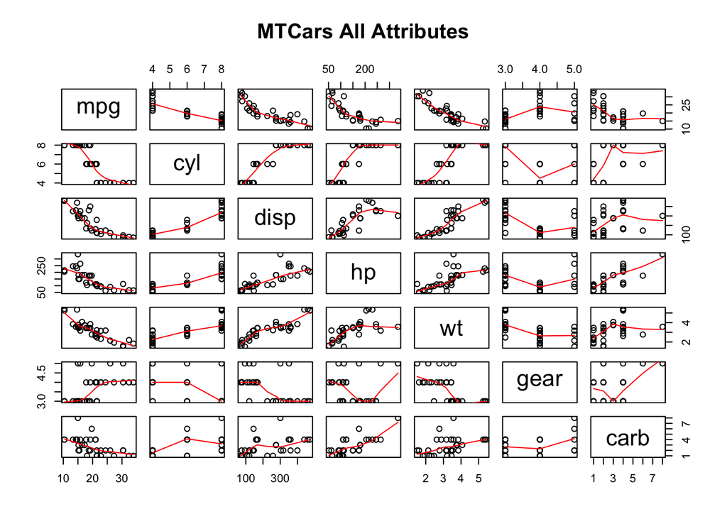

```r
all_vars <- c('mpg','cyl','disp','hp','wt','gear','carb')
pairs(x = mtcars[,all_vars], panel = panel.smooth, main = 'MTCars All Attributes')
```

A boxplot will show a quick comparison between Automatic and Manual data as it relates to MPG

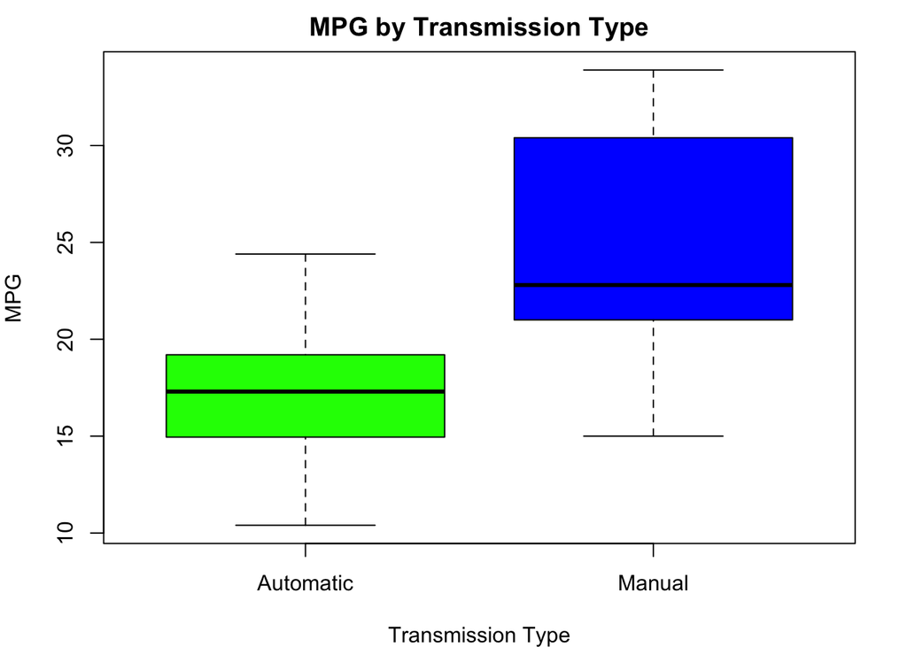

```r
par(mar = c(4, 4, 2,2))
par(mfrow = c(1, 1))
boxplot(mpg ~ am, data = mtcars, names = c("Automatic", "Manual"),
        col = c("green", "blue"),
        xlab = "Transmission Type",
        ylab = "MPG",
        main = "MPG by Transmission Type")
```

From the data, Automatic transmission type cars have lower average MPG than Manual transmission type cars. Also, most of the data points for Automatic are distributed below Manual cars MPG. Manual transmission data has more variety than Automatic car. Although, it looks like MPG between types of transmission overlap and vary by other factors. It may mean that other features of the car can be added to determine best MPG.

Then, determine wether dependencies are met by metric mpg

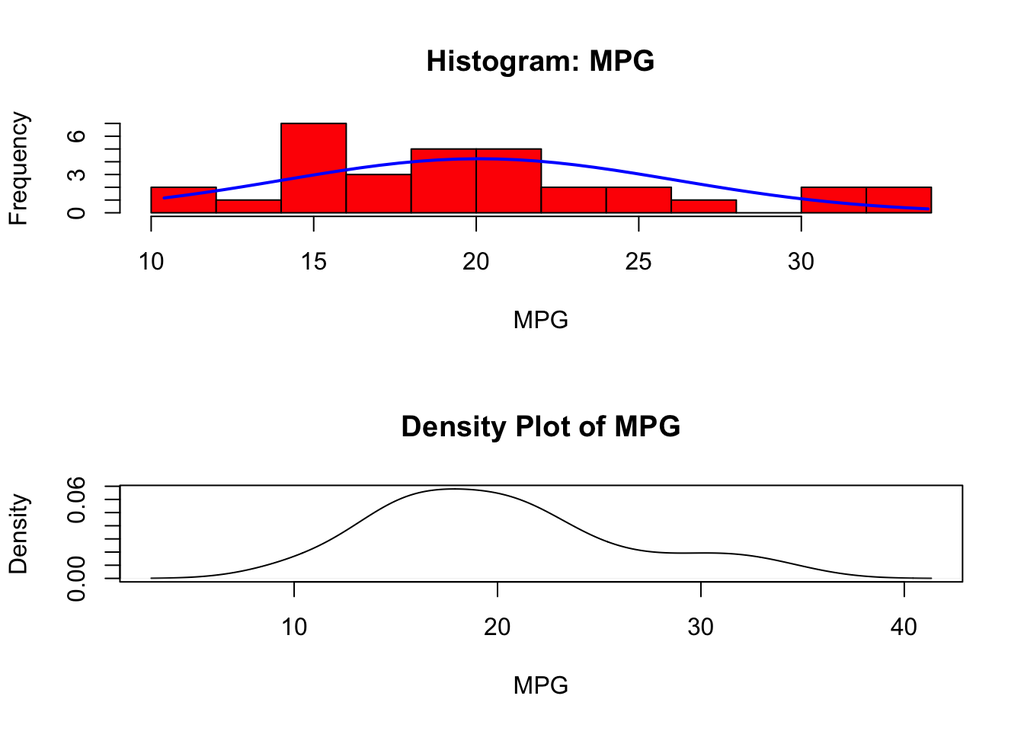

```r
par(mfrow = c(2, 1))
histMPG<-hist(mtcars$mpg, breaks=10, col="red", xlab="MPG", main="Histogram: MPG")

# Fit normal distribution to the histogram
xline <- seq(min(mtcars$mpg), max(mtcars$mpg), length=40)
yline <- dnorm(xline, mean=mean(mtcars$mpg), sd=sd(mtcars$mpg))
yline <- yline*diff(histMPG$mids[1:2])*length(mtcars$mpg)
lines(xline, yline, col="blue", lwd=2)

# Kernel Density Plot
plot(density(mtcars$mpg), xlab = "MPG", main ="Density Plot of MPG")
```

# Hypothesis Testing

Comparing the means by Transmission in the data.

```r
aggregate(mpg ~ am, data = mtcars, mean)
```

```
##          am      mpg
## 1 Automatic 17.14737
## 2    Manual 24.39231
```

NULL Hypothesis: The difference of MPG between manual and auto transmission is not significant

```r
autocars <- mtcars[mtcars$am == "Automatic",]
manualcars <- mtcars[mtcars$am == "Manual",]
t.test(autocars$mpg, manualcars$mpg)
```

```
##
##  Welch Two Sample t-test
##
## data:  autocars$mpg and manualcars$mpg
## t = -3.7671, df = 18.332, p-value = 0.001374
## alternative hypothesis: true difference in means is not equal to 0
## 95 percent confidence interval:
##  -11.280194  -3.209684
## sample estimates:
## mean of x mean of y
##  17.14737  24.39231
```

The p-value at 0.001374 tells us to reject the NULL hypothesis. The MPG difference is significant.

# Modeling and Regression

```r
# Linear Regression
fit <- lm(mpg~am, data = mtcars)
summary(fit)
```

```
##
## Call:
## lm(formula = mpg ~ am, data = mtcars)
##
## Residuals:
##     Min      1Q  Median      3Q     Max
## -9.3923 -3.0923 -0.2974  3.2439  9.5077
##
## Coefficients:
##             Estimate Std. Error t value Pr(>|t|)
## (Intercept)   17.147      1.125  15.247 1.13e-15 ***
## amManual       7.245      1.764   4.106 0.000285 ***
## ---
## Signif. codes:  0 '***' 0.001 '**' 0.01 '*' 0.05 '.' 0.1 ' ' 1
##
## Residual standard error: 4.902 on 30 degrees of freedom
## Multiple R-squared:  0.3598, Adjusted R-squared:  0.3385
## F-statistic: 16.86 on 1 and 30 DF,  p-value: 0.000285
```

Adjust R-squared is 0.3385, meaning this model only explains 33.85% of the of the variance bween MPG and transmission. We may need to add other features into the model

Here is a correlation matrix for the mtcars dataset that will help pinpoint other features to include in our model. This matrix looks at the correlation values with mpg:

```r
data(mtcars)
cor(mtcars)
```

```
##             mpg        cyl       disp         hp        drat         wt
## mpg   1.0000000 -0.8521620 -0.8475514 -0.7761684  0.68117191 -0.8676594
## cyl  -0.8521620  1.0000000  0.9020329  0.8324475 -0.69993811  0.7824958
## disp -0.8475514  0.9020329  1.0000000  0.7909486 -0.71021393  0.8879799
## hp   -0.7761684  0.8324475  0.7909486  1.0000000 -0.44875912  0.6587479
## drat  0.6811719 -0.6999381 -0.7102139 -0.4487591  1.00000000 -0.7124406
## wt   -0.8676594  0.7824958  0.8879799  0.6587479 -0.71244065  1.0000000
## qsec  0.4186840 -0.5912421 -0.4336979 -0.7082234  0.09120476 -0.1747159
## vs    0.6640389 -0.8108118 -0.7104159 -0.7230967  0.44027846 -0.5549157
## am    0.5998324 -0.5226070 -0.5912270 -0.2432043  0.71271113 -0.6924953
## gear  0.4802848 -0.4926866 -0.5555692 -0.1257043  0.69961013 -0.5832870
## carb -0.5509251  0.5269883  0.3949769  0.7498125 -0.09078980  0.4276059
##             qsec         vs          am       gear        carb
## mpg   0.41868403  0.6640389  0.59983243  0.4802848 -0.55092507
## cyl  -0.59124207 -0.8108118 -0.52260705 -0.4926866  0.52698829
## disp -0.43369788 -0.7104159 -0.59122704 -0.5555692  0.39497686
## hp   -0.70822339 -0.7230967 -0.24320426 -0.1257043  0.74981247
## drat  0.09120476  0.4402785  0.71271113  0.6996101 -0.09078980
## wt   -0.17471588 -0.5549157 -0.69249526 -0.5832870  0.42760594
## qsec  1.00000000  0.7445354 -0.22986086 -0.2126822 -0.65624923
## vs    0.74453544  1.0000000  0.16834512  0.2060233 -0.56960714
## am   -0.22986086  0.1683451  1.00000000  0.7940588  0.05753435
## gear -0.21268223  0.2060233  0.79405876  1.0000000  0.27407284
## carb -0.65624923 -0.5696071  0.05753435  0.2740728  1.00000000
```

```r
sort(cor(mtcars)[1,])
```

```
##         wt        cyl       disp         hp       carb       qsec
## -0.8676594 -0.8521620 -0.8475514 -0.7761684 -0.5509251  0.4186840
##       gear         am         vs       drat        mpg
##  0.4802848  0.5998324  0.6640389  0.6811719  1.0000000
```

- The fields wt, cyl, disp and hp are the top 4 correlated values to mpg, which will can be integrated into the multilinear regression model.  
  *The overall correlation matrix shows that hp and cyl are highly correlated so adding both these values together may confuse the model.

Additionally, more background information about the features will be valuable to consider which of these 4 features get added to the model.

```r
?mtcars
```

- cyl = number of cylinders
- disp = displacement
- hp = gross horsepower
- wt = weight

Adding Weight and Horsepower makes sense to add to the model. The heavier the car the less mpg expected. As well as the more horsepower then the more gas will be used to move the car.

```r
mfit <- lm(mpg ~ am + wt + hp, data = mtcars)
summary(mfit)
```

```
##
## Call:
## lm(formula = mpg ~ am + wt + hp, data = mtcars)
##
## Residuals:
##     Min      1Q  Median      3Q     Max
## -3.4221 -1.7924 -0.3788  1.2249  5.5317
##
## Coefficients:
##              Estimate Std. Error t value Pr(>|t|)
## (Intercept) 34.002875   2.642659  12.867 2.82e-13 ***
## am           2.083710   1.376420   1.514 0.141268
## wt          -2.878575   0.904971  -3.181 0.003574 **
## hp          -0.037479   0.009605  -3.902 0.000546 ***
## ---
## Signif. codes:  0 '***' 0.001 '**' 0.01 '*' 0.05 '.' 0.1 ' ' 1
##
## Residual standard error: 2.538 on 28 degrees of freedom
## Multiple R-squared:  0.8399, Adjusted R-squared:  0.8227
## F-statistic: 48.96 on 3 and 28 DF,  p-value: 2.908e-11
```

Summary of the multilinear regression model show a “better” R-squared (equals 0.8227), where 82% of the variance is explained by the model with weight and horsepower added.

```r
anova(fit, mfit)
```

```
## Analysis of Variance Table
##
## Model 1: mpg ~ am
## Model 2: mpg ~ am + wt + hp
##   Res.Df    RSS Df Sum of Sq      F    Pr(>F)
## 1     30 720.90
## 2     28 180.29  2    540.61 41.979 3.745e-09 ***
## ---
## Signif. codes:  0 '***' 0.001 '**' 0.01 '*' 0.05 '.' 0.1 ' ' 1
```

Anova table shows p-value = 3.745e-09, the null hypothesis can be rejected and the multivariate model is significantly different from the linear model.

Next, check the details of the multilinear regression model:

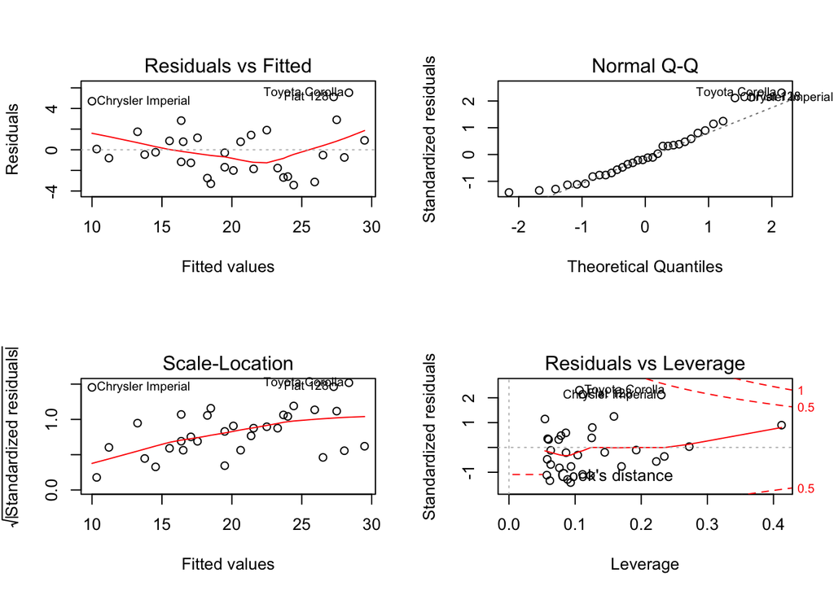

```r
par(mfrow = c(2,2))
plot(mfit)
```

```r
summary(mfit)
```

```
##
## Call:
## lm(formula = mpg ~ am + wt + hp, data = mtcars)
##
## Residuals:
##     Min      1Q  Median      3Q     Max
## -3.4221 -1.7924 -0.3788  1.2249  5.5317
##
## Coefficients:
##              Estimate Std. Error t value Pr(>|t|)
## (Intercept) 34.002875   2.642659  12.867 2.82e-13 ***
## am           2.083710   1.376420   1.514 0.141268
## wt          -2.878575   0.904971  -3.181 0.003574 **
## hp          -0.037479   0.009605  -3.902 0.000546 ***
## ---
## Signif. codes:  0 '***' 0.001 '**' 0.01 '*' 0.05 '.' 0.1 ' ' 1
##
## Residual standard error: 2.538 on 28 degrees of freedom
## Multiple R-squared:  0.8399, Adjusted R-squared:  0.8227
## F-statistic: 48.96 on 3 and 28 DF,  p-value: 2.908e-11
```

The coefficients show the mp and wt confounds the relationship between am and mpg. More of the confounded is created by wt. The am coefficient tells us that overall, manual trasmission cars have about 2.083 more mpg than automatic transmission.